# Проверка гипотез. Классические статистические тесты

# Требования к сдаче и оформлению задания

Заполните этот qmd-файл кодом и текстовыми ответами. Порядок сдачи задания описан в `README.md`. Требования ниже действуют для всех заданий, даже если в отдельном пункте они не повторяются.

1. Соблюдайте единый стиль оформления и структуру отчёта. Не оставляйте лишние блоки кода, текст или комментарии, которые не относятся к решению задания.
2. Ответы на вопросы, обоснования выбора методов и интерпретации результатов пишите обычным текстом, а не комментариями к коду. Код и его вывод, таблицы и графики не заменяют ответ на вопрос. Замените заглушки `*(ответ студента)*` своими ответами.
3. Численные результаты представляйте в тексте или аккуратных таблицах с понятными подписями. Не оставляйте необработанный консольный вывод или отдельные числа без пояснений. Допускается сохранять стандартный вывод функций статистических тестов, но его необходимо сопровождать текстовой интерпретацией.
4. После каждой проверки гипотезы сформулируйте текстовый вывод: укажите p-значение, уровень значимости и решение об отклонении или неотклонении нулевой гипотезы. Ответьте на исследовательский вопрос. Если в задании требуется доверительный интервал, объясните его смысл. Различайте статистическую и практическую (клиническую) значимость эффекта.
5. Графики должны быть достаточно крупными, с читаемыми русскими подписями, содержательным заголовком и правильно названными осями. Где применимо, указывайте единицы измерения. Не используйте фон ggplot2 по умолчанию.
6. Сохраняйте исходную структуру проекта в репозитории. Не добавляйте лишние файлы, которые не относятся к проекту или выполнению заданий.
7. Оформление коммитов и веток на GitHub должно соответствовать общим правилам для всех курсов Института биоинформатики.

# Настройка

Загрузите необходимые пакеты и установите seed.

```r
set.seed(42)
library(tidyverse)
library(epitools)
```

## Загрузка и проверка данных

В этом упражнении мы будем использовать данные NHANES (Национальное обследование здоровья и питания населения США). Подробное описание исходного набора данных и его переменных: [документация NHANES](https://cran.r-project.org/web/packages/NHANES/refman/NHANES.html).

Прочитайте предоставленный файл с данными.

```r
nhanes <- read.csv("data/nhanes.csv")
```

Проверьте размер и структуру таблицы, типы переменных и наличие пропущенных значений. Убедитесь, что данные прочитаны корректно.

Подготовьте данные для выполнения заданий:

1. Оставьте столбцы `ID`, `Gender`, `Age`, `BMI`, `BPSysAve`, `BPDiaAve`, `PhysActive`, `SleepTrouble`, `Height`, `Weight`, `Education` и `HHIncome`.
2. Оставьте только участников в возрасте 18 лет и старше.
3. Для простоты задания удалите строки, в которых есть хотя бы одно пропущенное значение среди оставленных столбцов.
4. Проверьте типы переменных и при необходимости преобразуйте их. Для порядковых признаков убедитесь, что порядок категорий соответствует их смыслу, а не алфавитному порядку.

Сохраните подготовленную таблицу в объект `nhanes_clean`. Сколько строк было до подготовки и сколько осталось после неё?

```r
n_before <- nrow(nhanes)
nhanes_clean <- nhanes %>%
  select(ID, Gender, Age, BMI, BPSysAve, BPDiaAve,
         PhysActive, SleepTrouble, Height, Weight,
         Education, HHIncome)
# Оставляем только участников 18 лет и старше
nhanes_clean <- nhanes_clean %>%
  filter(Age >= 18)
# Удаляем строки с пропущенными значениями
nhanes_clean <- nhanes_clean %>%
  drop_na()
# Проверяем и преобразуем типы переменных
nhanes_clean <- nhanes_clean %>%
  mutate(
    # Gender - категориальная переменная
    Gender = factor(Gender),
    # PhysActive - бинарная категориальная
    PhysActive = factor(PhysActive, levels = c("No", "Yes")),
    # SleepTrouble - бинарная категориальная
    SleepTrouble = factor(SleepTrouble, levels = c("No", "Yes")),
    # Education - порядковая переменная (от низшего к высшему образованию)
    Education = factor(Education,
                       levels = c("8th Grade",
                                  "9 - 11th Grade",
                                  "High School",
                                  "Some College or AA degree",
                                  "College Graduate"),
                       ordered = TRUE),
    # HHIncome - порядковая переменная (от низшего к высшему доходу)
    HHIncome = factor(HHIncome,
                      levels = c("Under 5000",
                                 "5000-9999",
                                 "10000-14999",
                                 "15000-19999",
                                 "20000-24999",
                                 "25000-34999",
                                 "35000-44999",
                                 "45000-54999",
                                 "55000-64999",
                                 "65000-74999",
                                 "75000-99999",
                                 "100000-149999",
                                 "150000-199999",
                                 "20000 or more"),
                      ordered = TRUE)
  )
# Количество строк после обработки
n_after <- nrow(nhanes_clean)
# Выводим результат
cat("Количество строк до обработки:", n_before, "\n")
```

```
Количество строк до обработки: 6779
```

```r
cat("Количество строк после обработки:", n_after, "\n")
```

```
Количество строк после обработки: 4032
```

```r
cat("Удалено строк:", n_before - n_after, "\n")
```

```
Удалено строк: 2747
```

```r
# Проверяем структуру данных
str(nhanes_clean)
```

```
'data.frame':   4032 obs. of  12 variables:
 $ ID          : int  51624 51630 51647 51654 51656 51657 51666 51667 51677 51678 ...
 $ Gender      : Factor w/ 2 levels "female","male": 2 1 1 2 2 2 1 2 2 2 ...
 $ Age         : int  34 49 45 66 58 54 58 50 33 60 ...
 $ BMI         : num  32.2 30.6 27.2 23.7 23.7 ...
 $ BPSysAve    : int  113 112 118 111 104 134 127 142 128 152 ...
 $ BPDiaAve    : int  85 75 64 63 74 85 83 68 74 100 ...
 $ PhysActive  : Factor w/ 2 levels "No","Yes": 1 1 2 2 2 2 2 2 1 1 ...
 $ SleepTrouble: Factor w/ 2 levels "No","Yes": 2 2 1 1 1 2 1 1 1 2 ...
 $ Height      : num  165 168 167 170 182 ...
 $ Weight      : num  87.4 86.7 75.7 68 78.4 74.7 57.5 84.1 93.8 74.6 ...
 $ Education   : Ord.factor w/ 5 levels "8th Grade"<"9 - 11th Grade"<..: 3 NA NA NA NA 2 3 NA 3 3 ...
 $ HHIncome    : Ord.factor w/ 14 levels "Under 5000"<"5000-9999"<..: 6 7 11 6 NA 10 11 4 6 4 ...
```

Ответ студента: Количество строк до обработки:6779 Количество строк после обработки:4032 Удалено строк:2747

# Тесты для непрерывных данных

## Параметрические тесты

### 1. Сравнение ИМТ с историческим средним

На основе исторических данных среднее значение ИМТ (`BMI`) для взрослых в США составляет **28.5**. ИМТ (индекс массы тела) рассчитывается как масса в килограммах, делённая на квадрат роста в метрах: $\mathrm{ИМТ} = \text{масса (кг)} / \text{рост (м)}^2$. Вопрос исследования: отличается ли среднее значение ИМТ в популяции взрослых (возраст ≥ 18) от исторического значения **28.5**?

#### Задание 1.1

Сформулируйте нулевую и альтернативную гипотезы.

- $H_0$: Среднее значение ИМТ в популяции взрослых (возраст ≥ 18) равно историческому значению 28.5
- $H_a$: Среднее значение ИМТ в популяции взрослых (возраст ≥ 18) не равно историческому значению 28.5

#### Задание 1.2

Посчитайте ключевые статистики (среднее, стандартное отклонение, размер выборки) для переменной `BMI` в вашем чистом наборе данных `nhanes_clean`.

```r
#Ключевые статистики для BMI
bmi_mean <- mean(nhanes_clean$BMI)
bmi_sd <- sd(nhanes_clean$BMI)
bmi_n <- length(nhanes_clean$BMI)

cat("Среднее BMI:", bmi_mean, "\n")
```

```
Среднее BMI: 28.99308
```

```r
cat("Стандартное отклонение BMI:", bmi_sd, "\n")
```

```
Стандартное отклонение BMI: 6.849808
```

```r
cat("Размер выборки (n):", bmi_n, "\n")
```

```
Размер выборки (n): 4032
```

#### Задание 1.3

Выберите подходящий статистический тест для проверки гипотез из задания 1.1 и объясните свой выбор.

Одновыборочный t-тест Анализируемая переменная BMI (ИМТ) является непрерывной (количественной). У нас есть только одна выборка и мы сравниваем её выборочное среднее значение с известным теоретическим (историческим) значением генеральной совокупности. Параметрический t-тест предполагает нормальное распределение данных или достаточно большой размер выборки. У нас большая выборка и распределение стремится к нормальному.

#### Задание 1.4

Используя выбранный тест, проверьте гипотезы из задания 1.1 на уровне значимости α = 0.1.

```r
mu_0_bmi <- 28.5

t.test(nhanes_clean$BMI, mu = mu_0_bmi, conf.level = 0.90)
```

```
    One Sample t-test

data:  nhanes_clean$BMI
t = 4.5709, df = 4031, p-value = 5.003e-06
alternative hypothesis: true mean is not equal to 28.5
90 percent confidence interval:
 28.81560 29.17056
sample estimates:
mean of x
 28.99308
```

#### Задание 1.5

Как p-значение и 90% доверительный интервал информируют вас об общем статусе ИМТ этой популяции относительно среднего значения в общей популяции в 28.5? Что вы можете сказать про статистическую значимость?

Статистическая значимость: Полученное p-значение значительно меньше заданного уровня значимости α=0.1. Следовательно, мы отвергаем нулевую гипотезу. 90% доверительный интервал для истинного среднего ИМТ в популяции составляет [28.82;29.17]. Поскольку историческое значение 28.5 НЕ попадает в этот интервал, это дополнительно подтверждает, что среднее значение ИМТ в нашей выборке статистически значимо отличается от исторического. Но несмотря на высокую статистическую значимость, выборочное среднее ИМТ (28.99) отличается от исторического (28.5) всего на 0.49 кг/м². С клинической точки зрения такая небольшая разница вряд ли имеет практическое значение для оценки здоровья популяции в целом. Высокая статистическая значимость в данном случае достигнута исключительно за счет очень большого размера выборки, который делает статистический тест сверхчувствительным к любым, даже минимальным отклонениям.

### 2. Сравнение давления у мужчин и женщин

Сценарий: Исследователи хотят сравнить систолическое артериальное давление у мужчин и женщин. Вопрос исследования: есть ли статистически значимая разница в среднем систолическом артериальном давлении (`BPSysAve`) между **мужчинами** и **женщинами**?

#### Задание 2.1

Сформулируйте нулевую и альтернативную гипотезы.

- $H_0$: Среднее систолическое артериальное давление у мужчин и женщин одинаково
- $H_a$: Среднее систолическое артериальное давление у мужчин и женщин различается

Подумайте, имеет ли значение, в какой группе давление больше.

С медицинской точки зрения направление различий важно (например, для оценки рисков ССЗ). Однако, поскольку исследовательский вопрос звучит как “есть ли разница” (без указания направления больше/меньше), мы формулируем двустороннюю альтернативную гипотезу, что μ давлений неравны

#### Задание 2.2

Посчитайте ключевые статистики (среднее в каждой группе, стандартное отклонение, размер каждой группы) для переменной `BPSysAve` в вашем чистом наборе данных `nhanes_clean`. Группы определяются переменной `Gender`.

```r
nhanes_clean %>%
  group_by(Gender) %>%
  summarise(
    n = n(),
    mean_BP = mean(BPSysAve),
    sd_BP = sd(BPSysAve)
  )
```

```
# A tibble: 2 × 4
  Gender     n mean_BP sd_BP
  <fct>  <int>   <dbl> <dbl>
1 female  2049    119.  18.3
2 male    1983    123.  15.9
```

#### Задание 2.3

Выберите подходящий статистический тест для проверки гипотез из задания 2.1 и объясните свой выбор.

Для проверки гипотезы выбран двухвыборочный t-критерий Стьюдента для независимых выборок. Мы сравниваем средние значения непрерывной переменной (систолическое артериальное давление, BPSysAve). Также сравнение проводится между двумя независимыми группами (мужчины и женщины). Хотя исходное распределение артериального давления в популяции может иметь отклонения от нормального, благодаря большому размеру выборки в каждой из групп, в силу ЦПТ, распределение выборочных средних близко к нормальному.

#### Задание 2.4

Используя выбранный тест, проверьте гипотезы из задания 2.1 на уровне значимости α = 0.1.

```r
t.test(BPSysAve ~ Gender, data = nhanes_clean, conf.level = 0.90)
```

```
    Welch Two Sample t-test

data:  BPSysAve by Gender
t = -7.7246, df = 3983.3, p-value = 1.41e-14
alternative hypothesis: true difference in means between group female and group male is not equal to 0
90 percent confidence interval:
 -5.047990 -3.275257
sample estimates:
mean in group female   mean in group male
            119.1742             123.3359
```

#### Задание 2.5

Как p-значение и 90% доверительный интервал информируют вас о разнице измеренного артериального давления между мужчинами и женщинами? Что вы можете сказать про статистическую значимость?

Статистическая значимость: Полученное p-значение значительно меньше заданного уровня значимости α=0.1. Следовательно, мы отвергаем нулевую гипотезу о равенстве среднего систолического артериального давления у мужчин и женщин. 90% доверительный интервал для разницы средних (женщины − мужчины) [−5.05;−3.28] мм рт. ст. Тот факт, что этот интервал не содержит ноль, дополнительно подтверждает статистическую значимость различий. Отрицательные значения границ интервала указывают на направление эффекта: среднее давление у женщин статистически значимо ниже, чем у мужчин. Практическая значимость: Несмотря на статистическую значимость (которая во многом обеспечена большим размером выборки), наблюдаемая разница в 4.2 мм рт.ст. является умеренной. Для конкретного пациента такая разница может находиться в пределах естественных суточных колебаний или погрешности измерения тонометра и вряд ли станет основанием для изменения тактики лечения. Но на популяционном уровне устойчивое различие систолического давления между полами в 4–5 мм рт.ст. считается биологически и клинически релевантным фактором, который учитывается при оценке общих рисков ССЗ.

### 3. Сравнение систолического и диастолического давления

Сценарий: Измерения систолического (`BPSysAve`) и диастолического (`BPDiaAve`) давления не являются независимыми. Вопрос исследования: равна ли нулю средняя **разница** между систолическим (`BPSysAve`) и диастолическим (`BPDiaAve`) давлением (пульсовое давление) в исследуемой популяции?

#### Задание 3.1

Сформулируйте нулевую и альтернативную гипотезы.

- $H_0$: Истинная средняя разница между систолическим и диастолическим артериальным давлением в популяции равна нулю
- $H_a$: Истинная средняя разница между систолическим и диастолическим артериальным давлением в популяции не равна нулю

Подумайте, имеет ли значение, в какой группе давление больше.

С физиологической точки зрения - ДА, имеет огромное значение. Систолическое давление (верхнее, в момент сокращения сердца) у здорового человека всегда выше диастолического (нижнего, в момент расслабления). Разница между ними называется пульсовым давлением и в норме составляет около 40–50 мм рт. ст. (например, 120- 80 = 40). Если диастолическое вдруг окажется выше систолического, это говорит о патологии или критическом состоянии пациента.

#### Задание 3.2

Посчитайте ключевые статистики для переменных `BPSysAve` и `BPDiaAve` в вашем чистом наборе данных `nhanes_clean`.

```r
nhanes_clean %>%
  summarise(
    n = n(),
    mean_Sys = mean(BPSysAve),
    sd_Sys = sd(BPSysAve),
    mean_Dia = mean(BPDiaAve),
    sd_Dia = sd(BPDiaAve),
    mean_diff = mean(BPSysAve - BPDiaAve),
    sd_diff = sd(BPSysAve - BPDiaAve)
  )
```

```
     n mean_Sys   sd_Sys mean_Dia   sd_Dia mean_diff  sd_diff
1 4032  121.221 17.26558 69.92336 12.75247  51.29762 17.97486
```

**Дополнительно (необязательное задание)** Визуализируйте эти параметры. Используйте боксплот, свяжите линиями измерения одного пациента.

```r
bp_long <- nhanes_clean %>%
  select(ID, BPSysAve, BPDiaAve) %>%
  pivot_longer(cols = c(BPSysAve, BPDiaAve),
               names_to = "BP_Type",
               values_to = "Pressure") %>%
  mutate(BP_Type = factor(BP_Type,
                          levels = c("BPDiaAve", "BPSysAve"),
                          labels = c("Диастолическое", "Систолическое")))
```

```
`geom_line()`: Each group consists of only one observation.
ℹ Do you need to adjust the group aesthetic?
```

[figure not shown]

```r
ggplot(bp_long, aes(x = BP_Type, y = Pressure)) +
  geom_boxplot(aes(fill = BP_Type), alpha = 0.6) +
  geom_line(aes(group = ID),
            data = dplyr::slice_sample(bp_long, n = 200),
            color = "gray50", alpha = 0.3) +
  labs(
    title = "Сравнение систолического и диастолического давления",
    subtitle = "Серые линии показывают траекторию для случайных 200 пациентов",
    x = "Тип артериального давления",
    y = "Давление (мм рт. ст.)"
  ) +
  theme_minimal() +
  theme(legend.position = "none")
```

#### Задание 3.3

Выберите подходящий статистический тест для проверки гипотез из задания 3.1 и объясните свой выбор.

Для проверки гипотезы выбран парный t-критерий Стьюдента, так как измерения систолического и диастолического давления получены от одних и тех же людей, то есть данные являются парными и зависимыми. ТАкже анализируемый признак (разница между давлениями) является непрерывным и благодаря большому размеру выборки, в силу ЦПТ, распределение выборочных средних разниц близко к нормальному, что делает применение параметрического теста корректным.

#### Задание 3.4

Используя выбранный тест, проверьте гипотезы из задания 3.1 на уровне значимости α = 0.1.

```r
t.test(nhanes_clean$BPSysAve, nhanes_clean$BPDiaAve,
       paired = TRUE,
       conf.level = 0.90)
```

```
    Paired t-test

data:  nhanes_clean$BPSysAve and nhanes_clean$BPDiaAve
t = 181.21, df = 4031, p-value < 2.2e-16
alternative hypothesis: true mean difference is not equal to 0
90 percent confidence interval:
 50.83189 51.76335
sample estimates:
mean difference
       51.29762
```

#### Задание 3.5

Как p-значение и 90% доверительный интервал информируют вас о разнице измеренного систолического и диастолического артериального давления? Что вы можете сказать про статистическую значимость?

Статистическая значимость: Полученное p-значение значительно меньше заданного уровня значимости α=0.1. Следовательно, мы отвергаем нулевую гипотезу о том, что истинная средняя разница равна нулю. 90% ДИ для средней разницы (пульсового давления) составляет [50.83;51.76] мм рт. ст. Тот факт, что этот интервал не содержит ноль и целиком находится в положительной области, дополнительно подтверждает статистическую значимость различий. Выборочное среднее значение разницы (51.30 мм рт. ст.) является центральной оценкой, вокруг которой построен этот ДИ. Практическая значимость: Выборочная средняя разница составила 51.30 мм рт. ст. С физиологической точки зрения это абсолютно ожидаемый и нормальный результат: систолическое давление (в момент сокращения сердца) всегда выше диастолического (в момент расслабления). Нормальное пульсовое давление у взрослых обычно составляет 30–50 мм рт. ст., а значение ~51 мм рт. ст. находится в пределах физиологической нормы (небольшое повышение характерно для взрослой популяции в целом). Таким образом, статистический тест подтвердил известный биологический факт, и наблюдаемая разница имеет высокую практическую значимость для понимания гемодинамики, не указывая при этом на какую-либо патологию в выборке в целом.

## Непараметрические тесты

Допустим, мы хотим сравнить статистическое доминирование ИМТ, а не средние абсолютные значения.

### 4. Сравнение ИМТ мужчин и женщин при помощи непараметрических тестов

Вопрос исследования: можно ли сказать, что значения ИМТ (`BMI`) у представителей одного пола, как правило, выше, чем у представителей другого?

#### Задание 4.1

Сформулируйте нулевую и альтернативную гипотезы.

- $H_0$: Медианы ИМТ у мужчин и женщин равны
- $H_a$: медианы ИМТ у мужчин и женщин НЕ равны

#### Задание 4.2

Посчитайте ключевые статистики (количество пациентов в каждой группе и другие статистики по необходимости).

```r
nhanes_clean %>%
  group_by(Gender) %>%
  summarise(
    n = n(),
    median_BMI = median(BMI),
    Q1 = quantile(BMI, 0.25),
    Q3 = quantile(BMI, 0.75),
    IQR_BMI = IQR(BMI)
  )
```

```
# A tibble: 2 × 6
  Gender     n median_BMI    Q1    Q3 IQR_BMI
  <fct>  <int>      <dbl> <dbl> <dbl>   <dbl>
1 female  2049       27.7  23.8  33.2    9.46
2 male    1983       27.9  24.8  31.7    6.91
```

Объясните, почему выбор статистик отличается для этого сценария от сценариев 1, 2 и 3.

В сценариях 1, 2 и 3 мы использовали параметрические тесты, которые опираются на предположение о нормальном распределении, поэтому мы считали среднее значение и стандартное отклонение. В сценарии 4 мы переходим к непараметрическому тесту (Манна-Уитни), который работает с рангами данных и не требует нормальности распределения. Поскольку ранговые тесты устойчивы к выбросам и асимметрии, среднее арифметическое теряет свою информативность. Поэтому для описания центра и разброса данных в этом сценарии корректно использовать медиану и интерквартильный размах (IQR).

#### Задание 4.3

Выберите подходящий статистический тест для проверки гипотез из задания 4.1 и объясните свой выбор. Имеет ли значение для выбора теста, сколько пациентов в каждой группе?

Являются ли группы зависимыми или независимыми?

Тест для этого блока - Критерий Манна-Уитни. Он используется для сравнения двух независимых групп, когда мы опираемся на ранги данных, а не на среднее значение и нормальность распределения. Группы независимые, так как мужчины и женщины – это разные люди, и измерение у одного не влияет на измерение у другого. Сам выбор теста зависит от типа данных и распределения, а не от размера выборки. Однако размер выборки важен для расчета p-значения: при малых выборках R использует точный метод, а при больших (как у нас) переключается на нормальную аппроксимацию. Также размер выборки напрямую влияет на статистическую мощность теста.

#### Задание 4.4

Проверьте гипотезы из задания 4.1 на уровне значимости α = 0.1.

```r
wilcox.test(BMI ~ Gender, data = nhanes_clean,
            conf.int = TRUE,
            conf.level = 0.90)
```

```
    Wilcoxon rank sum test with continuity correction

data:  BMI by Gender
W = 2008603, p-value = 0.534
alternative hypothesis: true location shift is not equal to 0
90 percent confidence interval:
 -0.4299676  0.1999964
sample estimates:
difference in location
            -0.1100318
```

#### Задание 4.5

На основании полученного p-значения сделайте вывод о различии между группами. Что вы можете сказать про статистическую значимость?

Статистическая значимость: Полученное p-значение значительно превышает заданный уровень значимости α=0.1. Следовательно, у нас нет оснований отвергнуть нулевую гипотезу. 90% доверительный интервал для сдвига локаций[−0.43;0.20]. Тот факт, что этот интервал содержит ноль, полностью согласуется с выводом теста и подтверждает отсутствие статистически значимой разницы между группами. Практическая значимость и вывод: На основании имеющихся данных мы не можем утверждать, что значения ИМТ у представителей одного пола, как правило, выше, чем у другого (статистическое доминирование отсутствует). Оценка разницы локаций составила всего −0.11, что является крайне малой величиной. С клинической и практической точки зрения такая разница не имеет никакого биологического смысла и подтверждает, что распределения ИМТ у мужчин и женщин в данной выборке практически идентичны.

### 5. Сравнение систолического и диастолического давления

Вопрос исследования: превосходят ли, как правило, значения одного типа артериального давления значения другого типа (САД и ДАД)? САД – систолическое артериальное давление, ДАД – диастолическое артериальное давление.

#### Задание 5.1

Сформулируйте нулевую и альтернативную гипотезы.

- $H_0$: Медиана разницы между систолическим и диастолическим давлением в популяции равна нулю. Нет систематического превосходства одного типа давления над другим
- $H_a$: Медиана разницы между систолическим и диастолическим давлением в популяции НЕ равна нулю. Систематическое превосходство существует одного типа давления над другим

#### Задание 5.2

Посчитайте ключевые статистики для переменных `BPSysAve` и `BPDiaAve` в вашем чистом наборе данных `nhanes_clean`. Обратите внимание, что это иные статистики, чем в задании 3.

```r
nhanes_clean1 <- nhanes_clean %>%
  mutate(PulsePressure = BPSysAve - BPDiaAve)

nhanes_clean1 %>%
  summarise(
    n = n(),
    median_diff = median(PulsePressure),
    Q1 = quantile(PulsePressure, 0.25),
    Q3 = quantile(PulsePressure, 0.75),
    IQR_diff = IQR(PulsePressure)
  )
```

```
     n median_diff Q1 Q3 IQR_diff
1 4032          48 39 59       20
```

**Дополнительно (необязательное задание)** Визуализируйте эти параметры. Используйте скрипичный график и боксплот, свяжите линиями измерения одного пациента. Визуально оцените, как выглядит распределение обеих переменных.

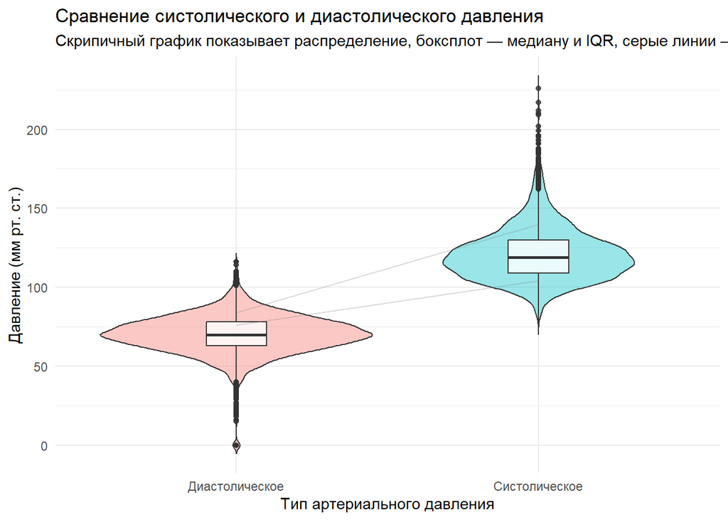

```r
bp_long1 <- nhanes_clean1 %>%
  select(ID, BPSysAve, BPDiaAve) %>%
  pivot_longer(cols = c(BPSysAve, BPDiaAve),
               names_to = "BP_Type",
               values_to = "Pressure") %>%
  mutate(BP_Type = factor(BP_Type,
                          levels = c("BPDiaAve", "BPSysAve"),
                          labels = c("Диастолическое", "Систолическое")))

ggplot(bp_long1, aes(x = BP_Type, y = Pressure)) +
  geom_violin(aes(fill = BP_Type), alpha = 0.4, trim = FALSE) +
  geom_boxplot(width = 0.2, alpha = 0.8) +
  geom_line(aes(group = ID),
            data = dplyr::slice_sample(bp_long1, n = 200),
            color = "gray50", alpha = 0.3) +
  labs(
    title = "Сравнение систолического и диастолического давления",
    subtitle = "Скрипичный график показывает распределение, боксплот — медиану и IQR, серые линии — парные измерения",
    x = "Тип артериального давления",
    y = "Давление (мм рт. ст.)"
  ) +
  theme_minimal() +
  theme(legend.position = "none")
```

#### Задание 5.3

Выберите подходящий статистический тест для проверки гипотез из задания 5.1 и объясните свой выбор.

Для проверки гипотезы выбран критерий знаковых рангов Уилкоксона для парных выборок (Wilcoxon signed-rank test). Выбран этот тест, так как измерения систолического и диастолического давления сняты с одних и тех же людей, то есть данные являются парными.Также в отличие от парного t-теста, критерий Уилкоксона не требует предположения о нормальном распределении разниц между парами. Он работает с рангами данных, что делает его устойчивым к выбросам и асимметрии распределения. Анализируемый признак (артериальное давление) является непрерывным, и мы оцениваем статистическое доминирование (сдвиг медианы разниц), а не разницу средних значений

#### Задание 5.4

Используя выбранный тест, проверьте гипотезы из задания 5.1 на уровне значимости α = 0.1.

```r
wilcox.test(nhanes_clean1$BPSysAve, nhanes_clean1$BPDiaAve,
            paired = TRUE,
            conf.int = TRUE,
            conf.level = 0.90)
```

```
    Wilcoxon signed rank test with continuity correction

data:  nhanes_clean1$BPSysAve and nhanes_clean1$BPDiaAve
V = 8130528, p-value < 2.2e-16
alternative hypothesis: true location shift is not equal to 0
90 percent confidence interval:
 48.99998 49.50000
sample estimates:
(pseudo)median
      49.00002
```

#### Задание 5.5

На основании полученного p-значения сделайте вывод о различии между систолическим и диастолическим артериальным давлением. Что вы можете сказать про статистическую значимость?

Статистическая значимость: Полученное p-значение значительно меньше заданного уровня значимости α=0.1. Следовательно, мы отвергаем нулевую гипотезу. 90% ДИ для сдвига локаций (оценки медианы разниц) составляет [49.00;49.50] мм рт. ст. Тот факт, что этот интервал не содержит ноль и целиком находится в положительной области, дополнительно подтверждает статистическую значимость различий. Это означает, что медиана разницы между систолическим и диастолическим давлением в популяции достоверно НЕ равна нулю.

Практическая значимость: Оценка пульсового давления составила 49 мм рт. ст. Это означает, что систолическое давление систематически превосходит диастолическое примерно на 49 мм рт. ст. С физиологической точки зрения это абсолютно ожидаемый и нормальный факт: нормальное пульсовое давление у взрослых обычно составляет 30–50 мм рт. ст. Таким образом, статистический тест подтвердил известную биологическую закономерность, и наблюдаемая разница имеет высокую практическую значимость для понимания гемодинамики, не указывая при этом на какую-либо патологию.

# Тесты для категориальных данных

### 6. Поиск зависимости между физической активностью и проблемами со сном

Вы хотите исследовать, есть ли взаимосвязь между проблемами со сном у человека и тем, занимается ли он физической активностью. Переменные: `PhysActive` — бинарный признак (`Yes` = занимается физической активностью, `No` = не занимается), `SleepTrouble` — бинарный признак (`Yes` = есть проблемы со сном, `No` = нет проблем).

#### Задание 6.1

Сформулируйте нулевую и альтернативную гипотезы для проверки связи между физической активностью и проблемами со сном. Какую альтернативу вы используете – одностороннюю или двустороннюю? Обоснуйте ответ

- $H_0$: Переменные “Физическая активность” и “Проблемы со сном” статистически независимы (между ними нет взаимосвязи).
- $H_a$: Переменные “Физическая активность” и “Проблемы со сном” статистически зависимы (между ними существует взаимосвязь).

Мы используем двустороннюю альтернативную гипотезу. Стандартный критерий Хи-квадрат проверяет наличие любого отклонения от независимости, независимо от направления. Хотя биологически мы можем предполагать, что спорт улучшает сон, статистически мы сначала должны доказать сам факт наличия связи, не навязывая тесту направление заранее.

#### Задание 6.2

Постройте таблицу сопряженности и визуализируйте ее. Исходя из полученной таблицы и иллюстрации, как вам кажется, похожи ли наши признаки на независимые? Почему?

```r
contingency_table <- table(nhanes_clean$PhysActive, nhanes_clean$SleepTrouble)
print(contingency_table)
```

```
        No  Yes
  No  1405  531
  Yes 1582  514
```

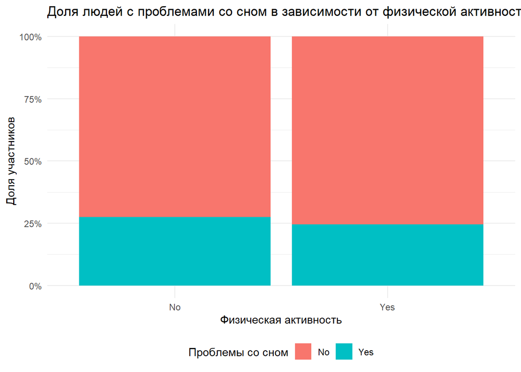

```r
ggplot(nhanes_clean, aes(x = PhysActive, fill = SleepTrouble)) +
  geom_bar(position = "fill") +
  scale_y_continuous(labels = scales::percent_format(accuracy = 1)) +
  labs(
    title = "Доля людей с проблемами со сном в зависимости от физической активности",
    x = "Физическая активность",
    y = "Доля участников",
    fill = "Проблемы со сном"
  ) +
  theme_minimal() +
  theme(legend.position = "bottom")
```

Таблица сопряженности показывает совместное распределение двух категориальных переменных. На основе данных можно рассчитать доли участников с проблемами со сном в каждой группе: Среди не занимающихся физической активностью (No): 531 из 1936 человек (27.4%) имеют проблемы со сном. Среди занимающихся физической активностью (Yes): 514 из 2096 человек (24.5%) имеют проблемы со сном.

Исходя из таблицы и пропорциональной столбчатой диаграммы, признаки не выглядят полностью независимыми. Если бы переменные были независимы, высота бирюзового сегмента (доля людей с проблемами со сном) была бы одинаковой в обоих столбцах. Однако на графике видно, что среди участников, занимающихся спортом, эта доля немного ниже (на 3%). Это предварительное визуальное наблюдение наводит на мысль о наличии слабой, но потенциальной статистической связи между физической активностью и качеством сна, которую мы проверим.

#### Задание 6.3

Какой статистический тест подходит для тестирования гипотезы из задания 6.1 (Хи-квадрат, Фишер, МакНемара)? Объясните свой выбор. Какие ограничения у выбранного теста? Если нужно, проверьте ограничения.

МакНемар не подходит, так как он используется только для парных категориальных данных (например, измерения “до/после” у одних и тех же людей). У нас же два разных признака у одних и тех же людей, но это не повторные измерения - это классическая таблица сопряженности для независимых групп. Для проверки гипотезы о связи между двумя категориальными переменными подходят критерий Хи-квадрат Пирсона и точный критерий Фишера. Основное ограничение критерия Хи-квадрат - все ожидаемые частоты в ячейках таблицы сопряженности должны быть не менее 5. В нашем случае выборка большая (более 4000 человек), и все наблюдаемые частоты в ячейках значительно превышают 5, поэтому ожидаемые частоты также будут заведомо больше 5. Следовательно, применение критерия Хи-квадрат обосновано и предпочтительно, так как он обладает большей мощностью для больших выборок. Точный тест Фишера также может быть использован как дополнительный метод проверки.

#### Задание 6.4

Используя выбранный тест, проверьте гипотезы из задания 6.1 на уровне значимости α = 0.05. Какое p-значение и значение статистики критерия получилось? Что вы можете сказать про статистическую значимость?

Совпадает ли результат статистического анализа с вашим предположением в задании 6.2? Если нет, попробуйте объяснить почему.

```r
# Критерий Хи-квадрат
chisq_result <- chisq.test(contingency_table)
print("Результат критерия Хи-квадрат:")
```

```
[1] "Результат критерия Хи-квадрат:"
```

```r
print(chisq_result)
```

```
    Pearson's Chi-squared test with Yates' continuity correction

data:  contingency_table
X-squared = 4.2728, df = 1, p-value = 0.03873
```

```r
# Точный тест Фишера (для сравнения)
fisher_result <- fisher.test(contingency_table)
print("Результат точного теста Фишера:")
```

```
[1] "Результат точного теста Фишера:"
```

```r
print(fisher_result)
```

```
    Fisher's Exact Test for Count Data

data:  contingency_table
p-value = 0.03697
alternative hypothesis: true odds ratio is not equal to 1
95 percent confidence interval:
 0.7447775 0.9923674
sample estimates:
odds ratio
 0.8597177
```

Критерий Хи-квадрат Пирсона (с поправкой Йетса на непрерывность) дал значение статистики 4.2728, p-значение = 0.03873. Точный критерий Фишера подтвердил результат: p-значение = 0.03697, отношение шансов = 0.860 с 95% ДИ [0.745; 0.992]. Статистическая значимость: Поскольку p-значение обоих тестов меньше заданного уровня значимости α = 0.05, мы отвергаем нулевую гипотезу о независимости переменных. Между физической активностью и проблемами со сном существует статистически значимая связь. Наш интервал [0.745; 0.992] не содержит единицу, что дополнительно подтверждает статистическую значимость. Значение odds ratio < 1 указывает на направление связи: у людей, занимающихся спортом, шансы иметь проблемы со сном ниже, чем у не занимающихся. Результат статистического анализа полностью совпадает с предварительным визуальным наблюдением. В задании 6.2 мы увидели, что доля людей с проблемами со сном среди занимающихся спортом ниже, чем среди не занимающихся на 3%, и предположили, что признаки не похожи на независимые. Тест Хи-квадрата подтвердил, что эта разница статистически значима (p < 0.05). Практическая значимость: Несмотря на статистическую значимость, наблюдаемая связь является слабой: разница в долях составляет всего около 3 процентных пунктов, а отношение шансов близко к 1. Высокая статистическая значимость здесь обеспечена в первую очередь большим размером выборки, который делает тест чувствительным даже к небольшим отклонениям. С клинической точки зрения такая слабая связь не может рассматриваться как самостоятельный фактор, определяющий качество сна.

#### Задание 6.5

Посчитайте размер эффекта (отношение шансов и отношение рисков, если это имеет смысл для этого исследования) двумя способами – самостоятельно (посчитайте дроби исходя из таблицы сопряженности), и с помощью пакета epitools, сравните результаты. Проинтерпретируйте результат с точки зрения клинической значимости (не забудьте про 95% доверительный интервал!). Прокомментируйте, почему вы решили считать или не считать отношение рисков.

```r
contingency_table <- table(
  "Физическая активность" = nhanes_clean$PhysActive,
  "Проблемы со сном" = nhanes_clean$SleepTrouble)
contingency_table
```

```
                     Проблемы со сном
Физическая активность   No  Yes
                  No  1405  531
                  Yes 1582  514
```

```r
# Шансы (Odds) и Риски (Risk/Prevalence) для группы "Нет спорта"
odds_no <- 531 / 1405
risk_no <- 531 / (531 + 1405)

# Шансы и Риски для группы "Есть спорт"
odds_yes <- 514 / 1582
risk_yes <- 514 / (514 + 1582)

# Отношение шансов (OR) и Отношение рисков (RR)
or_manual <- odds_yes / odds_no
rr_manual <- risk_yes / risk_no
or_manual
```

```
[1] 0.8596832
```

```r
rr_manual
```

```
[1] 0.894093
```

```r
#Расчет с помощью пакета epitools
OR <- oddsratio(contingency_table)
OR
```

```
$data
                     Проблемы со сном
Физическая активность   No  Yes Total
                No    1405  531  1936
                Yes   1582  514  2096
                Total 2987 1045  4032

$measure
                     odds ratio with 95% C.I.
Физическая активность  estimate     lower     upper
                  No  1.0000000        NA        NA
                  Yes 0.8597263 0.7466163 0.9898888

$p.value
                     two-sided
Физическая активность midp.exact fisher.exact chi.square
                  No          NA           NA         NA
                  Yes 0.03562128    0.0369677 0.03546257

$correction
[1] FALSE

attr(,"method")
[1] "median-unbiased estimate & mid-p exact CI"
```

```r
RR <- riskratio(contingency_table)
RR
```

```
$data
                     Проблемы со сном
Физическая активность   No  Yes Total
                No    1405  531  1936
                Yes   1582  514  2096
                Total 2987 1045  4032

$measure
                     risk ratio with 95% C.I.
Физическая активность estimate    lower     upper
                  No  1.000000       NA        NA
                  Yes 0.894093 0.805489 0.9924434

$p.value
                     two-sided
Физическая активность midp.exact fisher.exact chi.square
                  No          NA           NA         NA
                  Yes 0.03562128    0.0369677 0.03546257

$correction
[1] FALSE

attr(,"method")
[1] "Unconditional MLE & normal approximation (Wald) CI"
```

1. Сравнение ручного расчета и пакета epitools Ручной расчет, выполненный на основе таблицы сопряженности совпал с выводом функций oddsratio() и riskratio() из пакета epitools, что подтверждает корректность вычислений.
2. Интерпретация с учетом 95% доверительного интервала Для OR 95% ДИ составляет [0.747; 0.990]. Для RR 95% ДИ составляет [0.805; 0.992]. Поскольку ни один из этих доверительных интервалов не содержит единицу, мы делаем вывод о наличии статистически значимой связи. Значения меньше 1 указывают на то, что физическая активность ассоциирована со снижением вероятности проблем со сном.
3. Почему мы считаем отношение рисков в данном случае? Исследование является поперечным (cross-sectional). Мы не наблюдаем за людьми годами, чтобы увидеть, у кого возникнет проблема со сном. Мы просто фиксируем, есть ли проблема прямо сейчас (это распространенность). Также показатель Odds Ratio может математически преувеличивать силу эффекта по сравнению с отношением распространенности. В медицинской литературе для таких исследований отношение рисков считается более клинически релевантным и интуитивно понятным показателем.
4. Клиническая значимость Занятия физической активностью ассоциированы со снижением распространенности проблем со сном примерно на 11% (RR = 0.89) по сравнению с неактивными людьми. Несмотря на статистическую значимость (p ≈ 0.036), этот эффект является клинически слабым. Снижение риска на 11% указывает на то, что спорт является лишь одним из множества факторов, влияющих на сон, и не может рассматриваться как гарантированное или основное “лечение” инсомнии, хотя и вносит скромный положительный вклад в здоровье.

#### Задание 6.6

Исходя из результатов статистического анализа, можем ли мы сделать вывод, что физическая активность улучшает сон? Или что люди, которые лучше спят, чаще занимаются спортом?

Ответ: Нет, мы не можем сделать вывод о причинно-следственной связи на основе данного анализа. Мы можем утверждать лишь о наличии статистической ассоциации между этими двумя переменными. 1. Данные NHANES представляют собой поперечное (кросс-секционное) исследование. Мы измеряем физическую активность и наличие проблем со сном одновременно, в одной временной точке. Это не позволяет установить временную последовательность событий (что произошло раньше: человек начал заниматься спортом или у него наладился сон). 2. Вполне вероятен обратный сценарий: люди, которые изначально лучше спят, имеют больше энергии и мотивации для регулярных физических нагрузок, в то время как хроническая бессонница приводит к усталости и снижению активности. 3. Конфаундеры: Наблюдаемая связь может быть ложной или опосредованной третьими переменными, которые мы не контролировали в этом простом анализе (например микробиотой кишечника или питанием (если бы эти данные были), депрессией, возрастом). Вывод: Для доказательства того, что физическая активность именно улучшает сон, необходимы лонгитюдные исследования, отслеживающие изменения во времени, или РКИ, где физическая активность выступает в качестве контролируемого вмешательства.

# Поиск зависимостей между количественными / порядковыми признаками

### 7. Анализ зависимости между ростом и массой тела

Вопрос исследования: есть ли линейная связь между ростом (`Height`) и массой тела (`Weight`) у участников NHANES в возрасте 18 лет и старше?

#### Задание 7.1

Сформулируйте нулевую и альтернативную гипотезы.

- $H_0$: Между ростом и массой тела в популяции отсутствует линейная связь
- $H_a$: Между ростом и массой тела в популяции существует линейная связь

#### Задание 7.2

Визуализируйте распределения анализируемых переменных. Визуально оцените форму распределений и наличие выбросов.

Постройте диаграмму рассеяния роста (`Height`) и массы тела (`Weight`) (график должен быть читаемым), оцените линейность связи признаков.

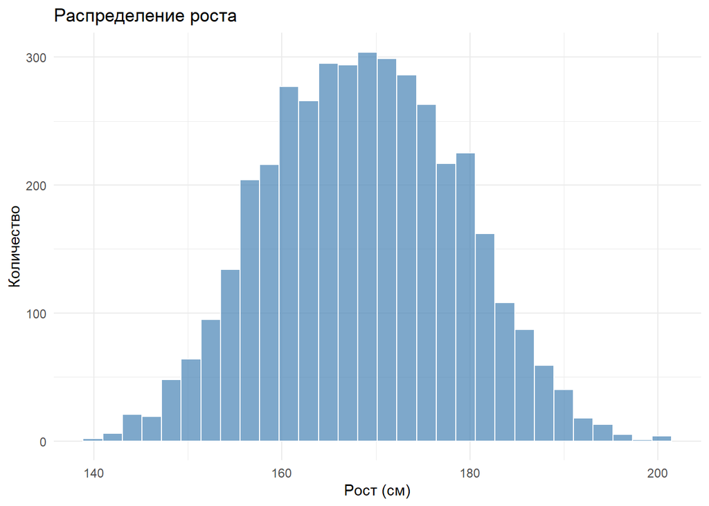

```r
#Оценка распределений (гистограммы)
p_height <- ggplot(nhanes_clean, aes(x = Height)) +
  geom_histogram(fill = "steelblue", alpha = 0.7, bins = 30, color = "white") +
  labs(title = "Распределение роста", x = "Рост (см)", y = "Количество") +
  theme_minimal()

p_weight <- ggplot(nhanes_clean, aes(x = Weight)) +
  geom_histogram(fill = "darkorange", alpha = 0.7, bins = 30, color = "white") +
  labs(title = "Распределение массы тела", x = "Масса тела (кг)", y = "Количество") +
  theme_minimal()

print(p_height)
```

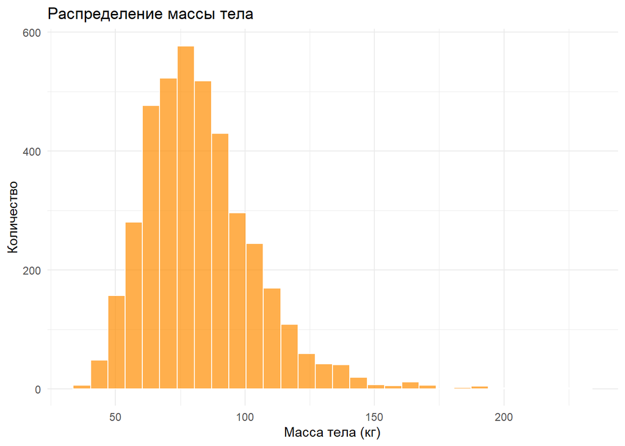

```r
print(p_weight)
```

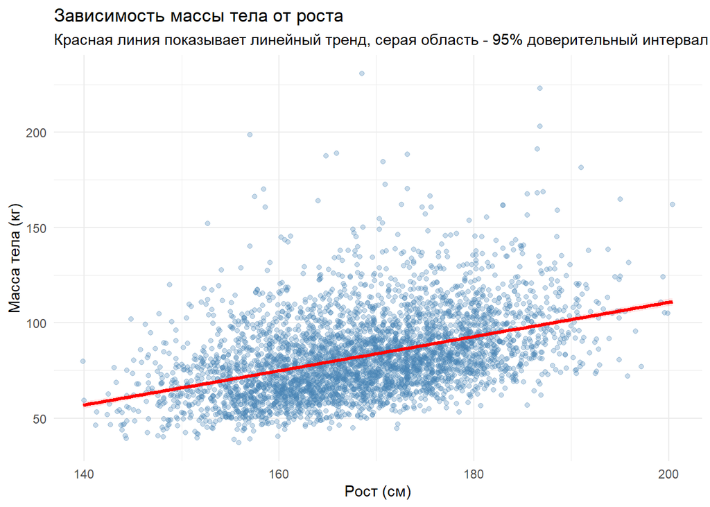

```r
# Диаграмма рассеяния для оценки линейности связи
ggplot(nhanes_clean, aes(x = Height, y = Weight)) +
  geom_point(color = "steelblue", alpha = 0.3, size = 1.5) +
  geom_smooth(method = "lm", color = "red", linewidth = 1.2, fill = "red", alpha = 0.1) +
  labs(
    title = "Зависимость массы тела от роста",
    subtitle = "Красная линия показывает линейный тренд, серая область - 95% доверительный интервал",
    x = "Рост (см)",
    y = "Масса тела (кг)"
  ) +
  theme_minimal()
```

Рост: Распределение близко к нормальному. Это типичная картина для смешанной выборки мужчин и женщин, у которых средние значения роста различаются. Выбросы присутствуют (единичные значения около 140 см и 200 см), но их количество невелико, и они не оказывают существенного влияния на общую форму распределения.

Масса тела: Распределение имеет выраженную правостороннюю (положительную) асимметрию — основной пик приходится на диапазон 70–80 кг, за которым следует длинный «хвост» вправо, уходящий к значениям 150–200 кг. Это означает, что в выборке присутствует значительная группа людей с очень высокой массой тела.

#### Задание 7.3

Выберите подходящий статистический тест для проверки гипотезы из задания 7.1 и объясните свой выбор.

Используя выбранный тест, проверьте гипотезы из задания 7.1 на уровне значимости α = 0.05.

Оцените величину наблюдаемого эффекта.

```r
#Корреляция Спирмена
cor_spearman <- cor.test(nhanes_clean$Height, nhanes_clean$Weight,
                         method = "spearman",
                         conf.level = 0.95)
cat("\nКорреляция Спирмена\n")
```

```
Корреляция Спирмена
```

```r
print(cor_spearman)
```

```
    Spearman's rank correlation rho

data:  nhanes_clean$Height and nhanes_clean$Weight
S = 5992835150, p-value < 2.2e-16
alternative hypothesis: true rho is not equal to 0
sample estimates:
      rho
0.4514427
```

```r
#Корреляция Пирсона (для сравнения)
cor_pearson <- cor.test(nhanes_clean$Height, nhanes_clean$Weight,
                        method = "pearson",
                        conf.level = 0.95)

cat("\nКорреляция Пирсона\n")
```

```
Корреляция Пирсона
```

```r
print(cor_pearson)
```

```
    Pearson's product-moment correlation

data:  nhanes_clean$Height and nhanes_clean$Weight
t = 29.761, df = 4030, p-value < 2.2e-16
alternative hypothesis: true correlation is not equal to 0
95 percent confidence interval:
 0.3988381 0.4494593
sample estimates:
      cor
0.4244803
```

Для проверки гипотезы о связи между ростом и массой тела был выбран коэффициент ранговой корреляции Спирмена. Хотя классический коэффициент корреляции Пирсона оценивает именно линейную связь (но Пирсона тоже считаем для сравнения), он требует предположения о нормальном распределении обеих переменных и крайне чувствителен к выбросам. Уже было показано выше, что распределение массы тела имеет выраженную правостороннюю асимметрию и содержит экстремальные значения. Корреляция Спирмена является непараметрическим методом: она работает с рангами значений, а не с их абсолютными величинами, что делает её более устойчивой к выбросам и нарушениям нормальности. Она оценивает связь, при которой с ростом одной переменной другая имеет тенденцию возрастать.

#### Задание 7.4

Как p-значение и 95% доверительный интервал информируют вас о силе и направлении связи между ростом и весом? Что вы можете сказать про статистическую и практическую значимость результата?

Статистическая значимость: p-значение значительно меньше заданного уровня значимости α=0.05, поэтому мы отвергаем нулевую гипотезу об отсутствии связи между ростом и массой тела. Для Пирсона 95% доверительный интервал составляет [0.399; 0.449]. Этот интервал не содержит ноль и целиком находится в положительной области, что дополнительно подтверждает статистическую значимость и положительное направление связи.

Оба коэффициента корреляции положительны, что указывает на прямую (положительную) связь: с увеличением роста масса тела имеет тенденцию возрастать. Связь умеренная, около 0.42-0.45.

Практическая значимость: Наблюдаемая умеренная положительная связь имеет очевидный биологический смысл — более высокие люди в среднем имеют бо́льшую массу тела. Однако коэффициент корреляции, далёкий от 1, показывает, что рост объясняет лишь часть вариации веса. Таким образом, связь между ростом и весом является статистически значимой и биологически ожидаемой, но не является определяющей для массы тела конкретного человека. На практике это означает, что по одному только росту невозможно точно предсказать вес - для этого нужны дополнительные антропометрические и клинические данные.

### 8. Анализ зависимости между образованием и доходом

Вопрос исследования: существует ли связь между уровнем образования (`Education`) и доходом домохозяйства (`HHIncome`) у участников NHANES в возрасте 18 лет и старше?

#### Задание 8.1

Сформулируйте нулевую и альтернативную гипотезы.

- $H_0$: Между уровнем образования и доходом домохозяйства отсутствует монотонная связь
- $H_a$: Между уровнем образования и доходом домохозяйства существует монотонная связь

#### Задание 8.2

Постройте диаграмму рассеяния, которая позволит визуализировать связь между изучаемыми переменными.

```r
#Упорядочивание факторов и удаление пропусков (NA)
nhanes_plot <- nhanes %>%
  filter(!is.na(Education), !is.na(HHIncome)) %>%
  mutate(
    #Упорядочиваем образование от низшего к высшему
    Education = factor(Education,
                       levels = c("8th Grade", "9 - 11th Grade", "High School",
                                  "Some College", "College Grad"),
                       ordered = TRUE),

    #Упорядочиваем доход от низшего к высшему
    HHIncome = factor(trimws(HHIncome),
                      levels = c("0-4999", "5000-9999", "10000-14999", "15000-19999",
                                 "20000-24999", "25000-34999", "35000-44999", "45000-54999",
                                 "55000-64999", "65000-74999", "75000-99999", "more 99999"),
                      ordered = TRUE)
  )
```

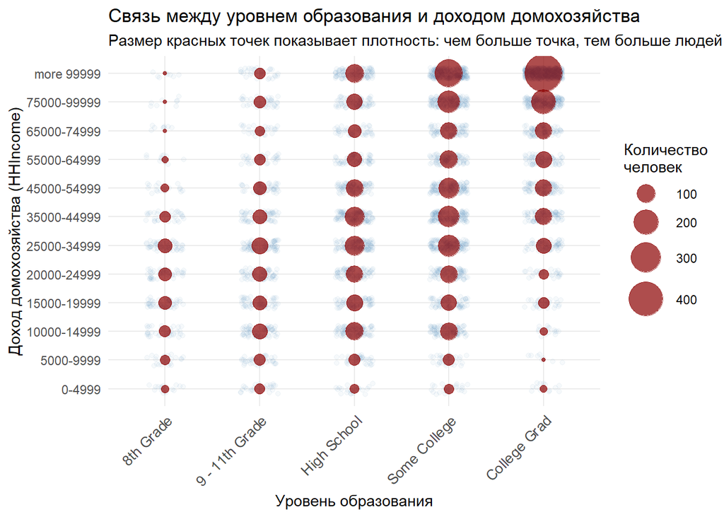

```r
ggplot(nhanes_plot, aes(x = Education, y = HHIncome)) +
  geom_jitter(width = 0.2, height = 0.2, alpha = 0.05, color = "steelblue") +
  geom_count(color = "darkred", alpha = 0.7) +
  scale_size_continuous(range = c(1, 12), name = "Количество\nчеловек") +
  labs(
    title = "Связь между уровнем образования и доходом домохозяйства",
    subtitle = "Размер красных точек показывает плотность: чем больше точка, тем больше людей с таким образованием имеют такой доход",
    x = "Уровень образования",
    y = "Доход домохозяйства (HHIncome)"
  ) +
  theme_minimal() +
  theme(
    axis.text.x = element_text(angle = 45, hjust = 1, size = 10),
    panel.grid.minor = element_blank()
  )
```

Поскольку обе переменные являются порядковыми, построена модифицированная диаграмма рассеяния с использованием geom_count, где размер точки пропорционален количеству наблюдений в каждой ячейке.

#### Задание 8.3

Выберите подходящий статистический тест для проверки гипотезы из задания 8.1 и объясните свой выбор.

Используя выбранный тест, проверьте гипотезы из задания 8.1 на уровне значимости α = 0.05.

Оцените величину наблюдаемого эффекта.

```r
# Корреляция Спирмена
cor_edu_inc <- cor.test(as.numeric(nhanes_clean$Education),
                        as.numeric(nhanes_clean$HHIncome),
                        method = "spearman",
                        conf.level = 0.95)
print(cor_edu_inc)
```

```
    Spearman's rank correlation rho

data:  as.numeric(nhanes_clean$Education) and as.numeric(nhanes_clean$HHIncome)
S = 390866877, p-value = 2.279e-07
alternative hypothesis: true rho is not equal to 0
sample estimates:
      rho
0.1379666
```

Для проверки гипотезы выбран коэффициент ранговой корреляции Спирмена. Этот выбор обусловлен природой данных: обе анализируемые переменные являются порядковыми (категориальными), а не непрерывными числовыми. Корреляция Пирсона здесь неприменима, так как она требует нормального распределения и измеряет строгую линейную связь. Корреляция Спирмена работает с рангами значений, что делает её хорошим инструментом для оценки наличия монотонной связи.

#### Задание 8.4

Как p-значение и значение коэффициента корреляции информируют вас о силе и направлении связи между уровнем образования и доходом домохозяйства? Что вы можете сказать про статистическую и практическую значимость результата?